# Risk Factor Analysis

## Outcome Variable

**Outcome Variable:** sstunted

## Predictor Variables

**Intervention Variable:** hhwealth_quart

**Adjustment Set:**

unadjusted

## Stratifying Variables

The analysis was stratified on these variable(s):

- agecat
- studyid
- country

## Data Summary

| agecat | studyid | country | hhwealth_quart | sstunted | n_cell | n | outcome_variable |
| --- | --- | --- | --- | --- | --- | --- | --- |
| Birth | ki0047075b-MAL-ED | BANGLADESH | Wealth Q4 | 0 | 56 | 213 | sstunted |
| Birth | ki0047075b-MAL-ED | BANGLADESH | Wealth Q4 | 1 | 0 | 213 | sstunted |
| Birth | ki0047075b-MAL-ED | BANGLADESH | Wealth Q1 | 0 | 50 | 213 | sstunted |
| Birth | ki0047075b-MAL-ED | BANGLADESH | Wealth Q1 | 1 | 2 | 213 | sstunted |
| Birth | ki0047075b-MAL-ED | BANGLADESH | Wealth Q2 | 0 | 47 | 213 | sstunted |
| Birth | ki0047075b-MAL-ED | BANGLADESH | Wealth Q2 | 1 | 4 | 213 | sstunted |
| Birth | ki0047075b-MAL-ED | BANGLADESH | Wealth Q3 | 0 | 54 | 213 | sstunted |
| Birth | ki0047075b-MAL-ED | BANGLADESH | Wealth Q3 | 1 | 0 | 213 | sstunted |
| Birth | ki0047075b-MAL-ED | BRAZIL | Wealth Q4 | 0 | 10 | 60 | sstunted |
| Birth | ki0047075b-MAL-ED | BRAZIL | Wealth Q4 | 1 | 1 | 60 | sstunted |
| Birth | ki0047075b-MAL-ED | BRAZIL | Wealth Q1 | 0 | 20 | 60 | sstunted |
| Birth | ki0047075b-MAL-ED | BRAZIL | Wealth Q1 | 1 | 1 | 60 | sstunted |
| Birth | ki0047075b-MAL-ED | BRAZIL | Wealth Q2 | 0 | 16 | 60 | sstunted |
| Birth | ki0047075b-MAL-ED | BRAZIL | Wealth Q2 | 1 | 1 | 60 | sstunted |
| Birth | ki0047075b-MAL-ED | BRAZIL | Wealth Q3 | 0 | 11 | 60 | sstunted |
| Birth | ki0047075b-MAL-ED | BRAZIL | Wealth Q3 | 1 | 0 | 60 | sstunted |
| Birth | ki0047075b-MAL-ED | INDIA | Wealth Q4 | 0 | 8 | 41 | sstunted |
| Birth | ki0047075b-MAL-ED | INDIA | Wealth Q4 | 1 | 0 | 41 | sstunted |
| Birth | ki0047075b-MAL-ED | INDIA | Wealth Q1 | 0 | 13 | 41 | sstunted |
| Birth | ki0047075b-MAL-ED | INDIA | Wealth Q1 | 1 | 1 | 41 | sstunted |
| Birth | ki0047075b-MAL-ED | INDIA | Wealth Q2 | 0 | 9 | 41 | sstunted |
| Birth | ki0047075b-MAL-ED | INDIA | Wealth Q2 | 1 | 0 | 41 | sstunted |
| Birth | ki0047075b-MAL-ED | INDIA | Wealth Q3 | 0 | 9 | 41 | sstunted |
| Birth | ki0047075b-MAL-ED | INDIA | Wealth Q3 | 1 | 1 | 41 | sstunted |
| Birth | ki0047075b-MAL-ED | NEPAL | Wealth Q4 | 0 | 6 | 26 | sstunted |
| Birth | ki0047075b-MAL-ED | NEPAL | Wealth Q4 | 1 | 0 | 26 | sstunted |
| Birth | ki0047075b-MAL-ED | NEPAL | Wealth Q1 | 0 | 8 | 26 | sstunted |
| Birth | ki0047075b-MAL-ED | NEPAL | Wealth Q1 | 1 | 1 | 26 | sstunted |
| Birth | ki0047075b-MAL-ED | NEPAL | Wealth Q2 | 0 | 3 | 26 | sstunted |
| Birth | ki0047075b-MAL-ED | NEPAL | Wealth Q2 | 1 | 0 | 26 | sstunted |

[output cut: 386 more lines]

The following strata were considered:

- agecat: 24 months, studyid: ki0047075b-MAL-ED, country: BANGLADESH
- agecat: 24 months, studyid: ki0047075b-MAL-ED, country: BRAZIL
- agecat: 24 months, studyid: ki0047075b-MAL-ED, country: INDIA
- agecat: 24 months, studyid: ki0047075b-MAL-ED, country: NEPAL
- agecat: 24 months, studyid: ki0047075b-MAL-ED, country: PERU
- agecat: 24 months, studyid: ki0047075b-MAL-ED, country: SOUTH AFRICA
- agecat: 24 months, studyid: ki0047075b-MAL-ED, country: TANZANIA, UNITED REPUBLIC OF
- agecat: 24 months, studyid: ki1000108-CMC-V-BCS-2002, country: INDIA
- agecat: 24 months, studyid: ki1000108-IRC, country: INDIA
- agecat: 24 months, studyid: ki1017093b-PROVIDE, country: BANGLADESH
- agecat: 24 months, studyid: ki1066203-TanzaniaChild2, country: TANZANIA, UNITED REPUBLIC OF
- agecat: 24 months, studyid: ki1113344-GMS-Nepal, country: NEPAL
- agecat: 24 months, studyid: ki1114097-CONTENT, country: PERU
- agecat: 24 months, studyid: ki1135781-COHORTS, country: GUATEMALA
- agecat: 24 months, studyid: ki1135781-COHORTS, country: PHILIPPINES
- agecat: 24 months, studyid: ki1148112-LCNI-5, country: MALAWI
- agecat: 24 months, studyid: kiGH5241-JiVitA-3, country: BANGLADESH
- agecat: 24 months, studyid: kiGH5241-JiVitA-4, country: BANGLADESH
- agecat: 6 months, studyid: ki0047075b-MAL-ED, country: BANGLADESH
- agecat: 6 months, studyid: ki0047075b-MAL-ED, country: BRAZIL
- agecat: 6 months, studyid: ki0047075b-MAL-ED, country: INDIA
- agecat: 6 months, studyid: ki0047075b-MAL-ED, country: NEPAL
- agecat: 6 months, studyid: ki0047075b-MAL-ED, country: PERU
- agecat: 6 months, studyid: ki0047075b-MAL-ED, country: SOUTH AFRICA
- agecat: 6 months, studyid: ki0047075b-MAL-ED, country: TANZANIA, UNITED REPUBLIC OF
- agecat: 6 months, studyid: ki1000108-CMC-V-BCS-2002, country: INDIA
- agecat: 6 months, studyid: ki1000108-IRC, country: INDIA
- agecat: 6 months, studyid: ki1017093b-PROVIDE, country: BANGLADESH
- agecat: 6 months, studyid: ki1066203-TanzaniaChild2, country: TANZANIA, UNITED REPUBLIC OF
- agecat: 6 months, studyid: ki1113344-GMS-Nepal, country: NEPAL
- agecat: 6 months, studyid: ki1114097-CONTENT, country: PERU
- agecat: 6 months, studyid: ki1135781-COHORTS, country: GUATEMALA
- agecat: 6 months, studyid: ki1135781-COHORTS, country: PHILIPPINES
- agecat: 6 months, studyid: ki1148112-LCNI-5, country: MALAWI
- agecat: 6 months, studyid: kiGH5241-JiVitA-3, country: BANGLADESH
- agecat: 6 months, studyid: kiGH5241-JiVitA-4, country: BANGLADESH
- agecat: Birth, studyid: ki0047075b-MAL-ED, country: BANGLADESH
- agecat: Birth, studyid: ki0047075b-MAL-ED, country: BRAZIL
- agecat: Birth, studyid: ki0047075b-MAL-ED, country: INDIA
- agecat: Birth, studyid: ki0047075b-MAL-ED, country: NEPAL
- agecat: Birth, studyid: ki0047075b-MAL-ED, country: PERU
- agecat: Birth, studyid: ki0047075b-MAL-ED, country: SOUTH AFRICA
- agecat: Birth, studyid: ki0047075b-MAL-ED, country: TANZANIA, UNITED REPUBLIC OF
- agecat: Birth, studyid: ki1000108-CMC-V-BCS-2002, country: INDIA
- agecat: Birth, studyid: ki1000108-IRC, country: INDIA
- agecat: Birth, studyid: ki1017093b-PROVIDE, country: BANGLADESH
- agecat: Birth, studyid: ki1113344-GMS-Nepal, country: NEPAL
- agecat: Birth, studyid: ki1114097-CONTENT, country: PERU
- agecat: Birth, studyid: ki1135781-COHORTS, country: GUATEMALA
- agecat: Birth, studyid: ki1135781-COHORTS, country: PHILIPPINES
- agecat: Birth, studyid: kiGH5241-JiVitA-3, country: BANGLADESH
- agecat: Birth, studyid: kiGH5241-JiVitA-4, country: BANGLADESH

### Dropped Strata

Some strata were dropped due to rare outcomes:

- agecat: Birth, studyid: ki0047075b-MAL-ED, country: BANGLADESH
- agecat: Birth, studyid: ki0047075b-MAL-ED, country: BRAZIL
- agecat: Birth, studyid: ki0047075b-MAL-ED, country: INDIA
- agecat: Birth, studyid: ki0047075b-MAL-ED, country: NEPAL
- agecat: Birth, studyid: ki0047075b-MAL-ED, country: PERU
- agecat: Birth, studyid: ki0047075b-MAL-ED, country: SOUTH AFRICA
- agecat: Birth, studyid: ki0047075b-MAL-ED, country: TANZANIA, UNITED REPUBLIC OF
- agecat: Birth, studyid: ki1000108-CMC-V-BCS-2002, country: INDIA
- agecat: Birth, studyid: ki1000108-IRC, country: INDIA
- agecat: Birth, studyid: ki1017093b-PROVIDE, country: BANGLADESH
- agecat: Birth, studyid: ki1114097-CONTENT, country: PERU
- agecat: Birth, studyid: ki1135781-COHORTS, country: GUATEMALA
- agecat: 6 months, studyid: ki0047075b-MAL-ED, country: BANGLADESH
- agecat: 6 months, studyid: ki0047075b-MAL-ED, country: BRAZIL
- agecat: 6 months, studyid: ki0047075b-MAL-ED, country: INDIA
- agecat: 6 months, studyid: ki0047075b-MAL-ED, country: NEPAL
- agecat: 6 months, studyid: ki0047075b-MAL-ED, country: PERU
- agecat: 6 months, studyid: ki0047075b-MAL-ED, country: SOUTH AFRICA
- agecat: 6 months, studyid: ki0047075b-MAL-ED, country: TANZANIA, UNITED REPUBLIC OF
- agecat: 6 months, studyid: ki1000108-CMC-V-BCS-2002, country: INDIA
- agecat: 6 months, studyid: ki1000108-IRC, country: INDIA
- agecat: 6 months, studyid: ki1017093b-PROVIDE, country: BANGLADESH
- agecat: 6 months, studyid: ki1066203-TanzaniaChild2, country: TANZANIA, UNITED REPUBLIC OF
- agecat: 6 months, studyid: ki1113344-GMS-Nepal, country: NEPAL
- agecat: 6 months, studyid: ki1114097-CONTENT, country: PERU
- agecat: 24 months, studyid: ki0047075b-MAL-ED, country: BANGLADESH
- agecat: 24 months, studyid: ki0047075b-MAL-ED, country: BRAZIL
- agecat: 24 months, studyid: ki0047075b-MAL-ED, country: NEPAL
- agecat: 24 months, studyid: ki0047075b-MAL-ED, country: PERU
- agecat: 24 months, studyid: ki0047075b-MAL-ED, country: SOUTH AFRICA
- agecat: 24 months, studyid: ki1066203-TanzaniaChild2, country: TANZANIA, UNITED REPUBLIC OF
- agecat: 24 months, studyid: ki1114097-CONTENT, country: PERU

## Methods Detail

We’re interested in the causal parameters $E[Y_a]$ for all values of $a \in \mathcal{A}$. These parameters represent the mean outcome if, possibly contrary to fact, we intervened to set all units to have $A=a$. Under the randomization and positivity assumptions, these are identified by the statistical parameters $\psi_a=E_W[E_{Y|A,W}(Y|A=a,W)]$. In addition, we’re interested in the mean of $Y$, $E[Y]$ under no intervention (the observed mean). We will estimate these parameters by using SuperLearner to fit the relevant likelihood factors – $E_{Y|A,W}(Y|A=a,W)$ and $p(A=a|W)$, and then updating our likelihood fit using a joint TMLE.

For unadjusted analyses ($W=\{\}$), initial likelihoods were estimated using Lrnr_glm to estimate the simple $E(Y|A)$ and Lrnr_mean to estimate $p(A)$. For adjusted analyses, a small library containing Lrnr_glmnet, Lrnr_xgboost, and Lrnr_mean was used.

Having estimated these parameters, we will then use the delta method to estimate relative risks and attributable risks relative to a prespecified baseline level of $A$.

# Results Detail

## Results Plots

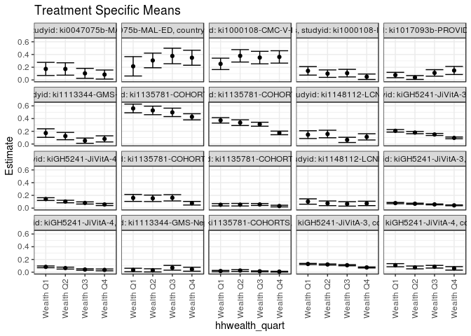

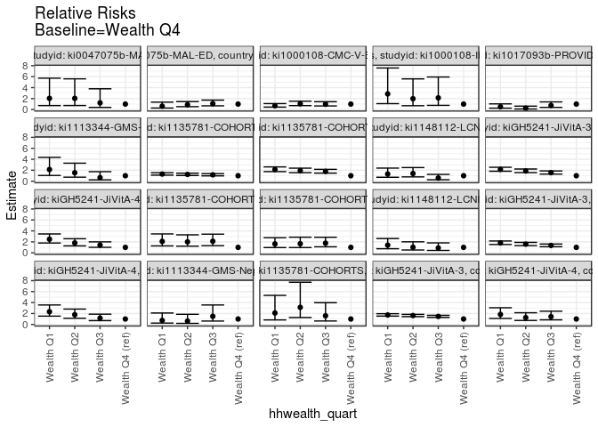

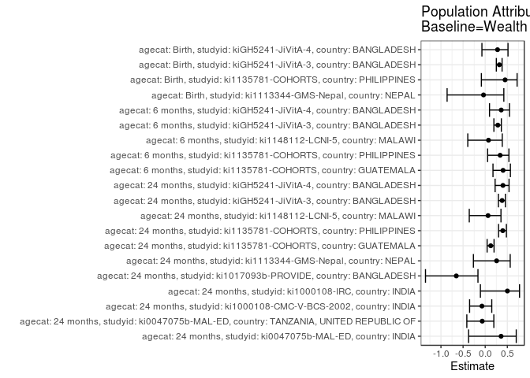

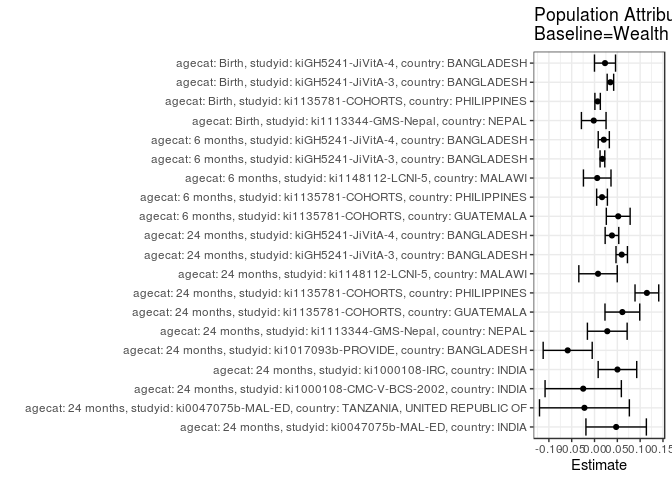

## Results Table

### Parameter: TSM

| agecat | studyid | country | intervention_level | baseline_level | estimate | ci_lower | ci_upper |
| --- | --- | --- | --- | --- | --- | --- | --- |
| Birth | ki1113344-GMS-Nepal | NEPAL | Wealth Q4 | NA | 0.0462428 | 0.0149259 | 0.0775596 |
| Birth | ki1113344-GMS-Nepal | NEPAL | Wealth Q1 | NA | 0.0342857 | 0.0073069 | 0.0612645 |
| Birth | ki1113344-GMS-Nepal | NEPAL | Wealth Q2 | NA | 0.0287356 | 0.0038949 | 0.0535764 |
| Birth | ki1113344-GMS-Nepal | NEPAL | Wealth Q3 | NA | 0.0689655 | 0.0312878 | 0.1066432 |
| Birth | ki1135781-COHORTS | PHILIPPINES | Wealth Q4 | NA | 0.0083135 | 0.0021795 | 0.0144475 |
| Birth | ki1135781-COHORTS | PHILIPPINES | Wealth Q1 | NA | 0.0174672 | 0.0076695 | 0.0272650 |
| Birth | ki1135781-COHORTS | PHILIPPINES | Wealth Q2 | NA | 0.0260223 | 0.0125676 | 0.0394771 |
| Birth | ki1135781-COHORTS | PHILIPPINES | Wealth Q3 | NA | 0.0132383 | 0.0060886 | 0.0203880 |
| Birth | kiGH5241-JiVitA-3 | BANGLADESH | Wealth Q4 | NA | 0.0742706 | 0.0663000 | 0.0822411 |
| Birth | kiGH5241-JiVitA-3 | BANGLADESH | Wealth Q1 | NA | 0.1288981 | 0.1201530 | 0.1376433 |
| Birth | kiGH5241-JiVitA-3 | BANGLADESH | Wealth Q2 | NA | 0.1210314 | 0.1122755 | 0.1297873 |
| Birth | kiGH5241-JiVitA-3 | BANGLADESH | Wealth Q3 | NA | 0.1094492 | 0.1005630 | 0.1183355 |
| Birth | kiGH5241-JiVitA-4 | BANGLADESH | Wealth Q4 | NA | 0.0596330 | 0.0324402 | 0.0868258 |
| Birth | kiGH5241-JiVitA-4 | BANGLADESH | Wealth Q1 | NA | 0.1094891 | 0.0850274 | 0.1339507 |
| Birth | kiGH5241-JiVitA-4 | BANGLADESH | Wealth Q2 | NA | 0.0747922 | 0.0526755 | 0.0969089 |
| Birth | kiGH5241-JiVitA-4 | BANGLADESH | Wealth Q3 | NA | 0.0856390 | 0.0647538 | 0.1065242 |
| 6 months | ki1135781-COHORTS | GUATEMALA | Wealth Q4 | NA | 0.0766962 | 0.0483534 | 0.1050389 |
| 6 months | ki1135781-COHORTS | GUATEMALA | Wealth Q1 | NA | 0.1600000 | 0.1056545 | 0.2143455 |
| 6 months | ki1135781-COHORTS | GUATEMALA | Wealth Q2 | NA | 0.1538462 | 0.1031782 | 0.2045141 |
| 6 months | ki1135781-COHORTS | GUATEMALA | Wealth Q3 | NA | 0.1620370 | 0.1128698 | 0.2112043 |
| 6 months | ki1135781-COHORTS | PHILIPPINES | Wealth Q4 | NA | 0.0323015 | 0.0195865 | 0.0450164 |
| 6 months | ki1135781-COHORTS | PHILIPPINES | Wealth Q1 | NA | 0.0526316 | 0.0342969 | 0.0709663 |
| 6 months | ki1135781-COHORTS | PHILIPPINES | Wealth Q2 | NA | 0.0536082 | 0.0335585 | 0.0736580 |
| 6 months | ki1135781-COHORTS | PHILIPPINES | Wealth Q3 | NA | 0.0571429 | 0.0420590 | 0.0722267 |
| 6 months | ki1148112-LCNI-5 | MALAWI | Wealth Q4 | NA | 0.0737327 | 0.0389404 | 0.1085250 |
| 6 months | ki1148112-LCNI-5 | MALAWI | Wealth Q1 | NA | 0.1034483 | 0.0615288 | 0.1453677 |
| 6 months | ki1148112-LCNI-5 | MALAWI | Wealth Q2 | NA | 0.0753769 | 0.0386749 | 0.1120788 |
| 6 months | ki1148112-LCNI-5 | MALAWI | Wealth Q3 | NA | 0.0659898 | 0.0313005 | 0.1006792 |
| 6 months | kiGH5241-JiVitA-3 | BANGLADESH | Wealth Q4 | NA | 0.0433387 | 0.0374264 | 0.0492510 |
| 6 months | kiGH5241-JiVitA-3 | BANGLADESH | Wealth Q1 | NA | 0.0786392 | 0.0691004 | 0.0881779 |
| 6 months | kiGH5241-JiVitA-3 | BANGLADESH | Wealth Q2 | NA | 0.0688508 | 0.0602500 | 0.0774516 |
| 6 months | kiGH5241-JiVitA-3 | BANGLADESH | Wealth Q3 | NA | 0.0582524 | 0.0512555 | 0.0652494 |
| 6 months | kiGH5241-JiVitA-4 | BANGLADESH | Wealth Q4 | NA | 0.0358632 | 0.0219054 | 0.0498211 |
| 6 months | kiGH5241-JiVitA-4 | BANGLADESH | Wealth Q1 | NA | 0.0836120 | 0.0699330 | 0.0972911 |
| 6 months | kiGH5241-JiVitA-4 | BANGLADESH | Wealth Q2 | NA | 0.0641132 | 0.0491017 | 0.0791248 |
| 6 months | kiGH5241-JiVitA-4 | BANGLADESH | Wealth Q3 | NA | 0.0414972 | 0.0299281 | 0.0530662 |
| 24 months | ki0047075b-MAL-ED | INDIA | Wealth Q4 | NA | 0.0847458 | 0.0135243 | 0.1559672 |
| 24 months | ki0047075b-MAL-ED | INDIA | Wealth Q1 | NA | 0.1730769 | 0.0700247 | 0.2761291 |
| 24 months | ki0047075b-MAL-ED | INDIA | Wealth Q2 | NA | 0.1724138 | 0.0749854 | 0.2698422 |
| 24 months | ki0047075b-MAL-ED | INDIA | Wealth Q3 | NA | 0.1034483 | 0.0248990 | 0.1819975 |
| 24 months | ki0047075b-MAL-ED | TANZANIA, UNITED REPUBLIC OF | Wealth Q4 | NA | 0.3492063 | 0.2312130 | 0.4671997 |
| 24 months | ki0047075b-MAL-ED | TANZANIA, UNITED REPUBLIC OF | Wealth Q1 | NA | 0.2142857 | 0.0619453 | 0.3666261 |
| 24 months | ki0047075b-MAL-ED | TANZANIA, UNITED REPUBLIC OF | Wealth Q2 | NA | 0.3064516 | 0.1914276 | 0.4214757 |
| 24 months | ki0047075b-MAL-ED | TANZANIA, UNITED REPUBLIC OF | Wealth Q3 | NA | 0.3770492 | 0.2551429 | 0.4989555 |
| 24 months | ki1000108-CMC-V-BCS-2002 | INDIA | Wealth Q4 | NA | 0.3617021 | 0.2644369 | 0.4589673 |
| 24 months | ki1000108-CMC-V-BCS-2002 | INDIA | Wealth Q1 | NA | 0.2527473 | 0.1633364 | 0.3421582 |
| 24 months | ki1000108-CMC-V-BCS-2002 | INDIA | Wealth Q2 | NA | 0.3789474 | 0.2812628 | 0.4766320 |
| 24 months | ki1000108-CMC-V-BCS-2002 | INDIA | Wealth Q3 | NA | 0.3516484 | 0.2534118 | 0.4498849 |
| 24 months | ki1000108-IRC | INDIA | Wealth Q4 | NA | 0.0500000 | 0.0072313 | 0.0927687 |
| 24 months | ki1000108-IRC | INDIA | Wealth Q1 | NA | 0.1428571 | 0.0758436 | 0.2098707 |
| 24 months | ki1000108-IRC | INDIA | Wealth Q2 | NA | 0.0990099 | 0.0406898 | 0.1573300 |
| 24 months | ki1000108-IRC | INDIA | Wealth Q3 | NA | 0.1067961 | 0.0470769 | 0.1665153 |
| 24 months | ki1017093b-PROVIDE | BANGLADESH | Wealth Q4 | NA | 0.1487603 | 0.0853002 | 0.2122205 |
| 24 months | ki1017093b-PROVIDE | BANGLADESH | Wealth Q1 | NA | 0.0774194 | 0.0353094 | 0.1195294 |
| 24 months | ki1017093b-PROVIDE | BANGLADESH | Wealth Q2 | NA | 0.0382166 | 0.0082015 | 0.0682316 |
| 24 months | ki1017093b-PROVIDE | BANGLADESH | Wealth Q3 | NA | 0.1103448 | 0.0593029 | 0.1613867 |
| 24 months | ki1113344-GMS-Nepal | NEPAL | Wealth Q4 | NA | 0.0806452 | 0.0326703 | 0.1286200 |
| 24 months | ki1113344-GMS-Nepal | NEPAL | Wealth Q1 | NA | 0.1721311 | 0.1050772 | 0.2391851 |
| 24 months | ki1113344-GMS-Nepal | NEPAL | Wealth Q2 | NA | 0.1250000 | 0.0676481 | 0.1823519 |
| 24 months | ki1113344-GMS-Nepal | NEPAL | Wealth Q3 | NA | 0.0526316 | 0.0115995 | 0.0936637 |
| 24 months | ki1135781-COHORTS | GUATEMALA | Wealth Q4 | NA | 0.4278607 | 0.3794717 | 0.4762497 |
| 24 months | ki1135781-COHORTS | GUATEMALA | Wealth Q1 | NA | 0.5594059 | 0.4909099 | 0.6279019 |
| 24 months | ki1135781-COHORTS | GUATEMALA | Wealth Q2 | NA | 0.5283019 | 0.4610719 | 0.5955319 |
| 24 months | ki1135781-COHORTS | GUATEMALA | Wealth Q3 | NA | 0.4977169 | 0.4314645 | 0.5639693 |
| 24 months | ki1135781-COHORTS | PHILIPPINES | Wealth Q4 | NA | 0.1744186 | 0.1460578 | 0.2027794 |
| 24 months | ki1135781-COHORTS | PHILIPPINES | Wealth Q1 | NA | 0.3721881 | 0.3293354 | 0.4150409 |
| 24 months | ki1135781-COHORTS | PHILIPPINES | Wealth Q2 | NA | 0.3356974 | 0.2906859 | 0.3807089 |
| 24 months | ki1135781-COHORTS | PHILIPPINES | Wealth Q3 | NA | 0.3112426 | 0.2800184 | 0.3424668 |
| 24 months | ki1148112-LCNI-5 | MALAWI | Wealth Q4 | NA | 0.1125000 | 0.0634965 | 0.1615035 |
| 24 months | ki1148112-LCNI-5 | MALAWI | Wealth Q1 | NA | 0.1472868 | 0.0860778 | 0.2084958 |
| 24 months | ki1148112-LCNI-5 | MALAWI | Wealth Q2 | NA | 0.1575342 | 0.0983898 | 0.2166787 |
| 24 months | ki1148112-LCNI-5 | MALAWI | Wealth Q3 | NA | 0.0647482 | 0.0238035 | 0.1056929 |
| 24 months | kiGH5241-JiVitA-3 | BANGLADESH | Wealth Q4 | NA | 0.0963652 | 0.0826241 | 0.1101062 |
| 24 months | kiGH5241-JiVitA-3 | BANGLADESH | Wealth Q1 | NA | 0.2073963 | 0.1878687 | 0.2269239 |
| 24 months | kiGH5241-JiVitA-3 | BANGLADESH | Wealth Q2 | NA | 0.1799620 | 0.1622490 | 0.1976750 |
| 24 months | kiGH5241-JiVitA-3 | BANGLADESH | Wealth Q3 | NA | 0.1502326 | 0.1341471 | 0.1663180 |
| 24 months | kiGH5241-JiVitA-4 | BANGLADESH | Wealth Q4 | NA | 0.0569992 | 0.0405688 | 0.0734295 |
| 24 months | kiGH5241-JiVitA-4 | BANGLADESH | Wealth Q1 | NA | 0.1418685 | 0.1205376 | 0.1631994 |
| 24 months | kiGH5241-JiVitA-4 | BANGLADESH | Wealth Q2 | NA | 0.1031543 | 0.0833118 | 0.1229968 |
| 24 months | kiGH5241-JiVitA-4 | BANGLADESH | Wealth Q3 | NA | 0.0808163 | 0.0639500 | 0.0976827 |

### Parameter: E(Y)

| agecat | studyid | country | intervention_level | baseline_level | estimate | ci_lower | ci_upper |
| --- | --- | --- | --- | --- | --- | --- | --- |
| Birth | ki1113344-GMS-Nepal | NEPAL | NA | NA | 0.0445402 | 0.0292033 | 0.0598771 |
| Birth | ki1135781-COHORTS | PHILIPPINES | NA | NA | 0.0150869 | 0.0107594 | 0.0194144 |
| Birth | kiGH5241-JiVitA-3 | BANGLADESH | NA | NA | 0.1091201 | 0.1045627 | 0.1136775 |
| Birth | kiGH5241-JiVitA-4 | BANGLADESH | NA | NA | 0.0826241 | 0.0709364 | 0.0943118 |
| 6 months | ki1135781-COHORTS | GUATEMALA | NA | NA | 0.1286486 | 0.1070607 | 0.1502366 |
| 6 months | ki1135781-COHORTS | PHILIPPINES | NA | NA | 0.0487445 | 0.0406327 | 0.0568562 |
| 6 months | ki1148112-LCNI-5 | MALAWI | NA | NA | 0.0796569 | 0.0610679 | 0.0982459 |
| 6 months | kiGH5241-JiVitA-3 | BANGLADESH | NA | NA | 0.0606439 | 0.0567894 | 0.0644985 |
| 6 months | kiGH5241-JiVitA-4 | BANGLADESH | NA | NA | 0.0561658 | 0.0493946 | 0.0629370 |
| 24 months | ki0047075b-MAL-ED | INDIA | NA | NA | 0.1321586 | 0.0880054 | 0.1763117 |
| 24 months | ki0047075b-MAL-ED | TANZANIA, UNITED REPUBLIC OF | NA | NA | 0.3271028 | 0.2640978 | 0.3901078 |
| 24 months | ki1000108-CMC-V-BCS-2002 | INDIA | NA | NA | 0.3369272 | 0.2887662 | 0.3850883 |
| 24 months | ki1000108-IRC | INDIA | NA | NA | 0.1002445 | 0.0711031 | 0.1293859 |
| 24 months | ki1017093b-PROVIDE | BANGLADESH | NA | NA | 0.0899654 | 0.0666186 | 0.1133122 |
| 24 months | ki1113344-GMS-Nepal | NEPAL | NA | NA | 0.1086066 | 0.0809724 | 0.1362407 |
| 24 months | ki1135781-COHORTS | GUATEMALA | NA | NA | 0.4888889 | 0.4584204 | 0.5193574 |
| 24 months | ki1135781-COHORTS | PHILIPPINES | NA | NA | 0.2891616 | 0.2711872 | 0.3071359 |
| 24 months | ki1148112-LCNI-5 | MALAWI | NA | NA | 0.1202091 | 0.0935816 | 0.1468365 |
| 24 months | kiGH5241-JiVitA-3 | BANGLADESH | NA | NA | 0.1559782 | 0.1472336 | 0.1647228 |
| 24 months | kiGH5241-JiVitA-4 | BANGLADESH | NA | NA | 0.0952180 | 0.0856733 | 0.1047628 |

### Parameter: RR

| agecat | studyid | country | intervention_level | baseline_level | estimate | ci_lower | ci_upper |
| --- | --- | --- | --- | --- | --- | --- | --- |
| Birth | ki1113344-GMS-Nepal | NEPAL | Wealth Q4 | Wealth Q4 | 1.0000000 | 1.0000000 | 1.000000 |
| Birth | ki1113344-GMS-Nepal | NEPAL | Wealth Q1 | Wealth Q4 | 0.7414286 | 0.2625388 | 2.093848 |
| Birth | ki1113344-GMS-Nepal | NEPAL | Wealth Q2 | Wealth Q4 | 0.6214080 | 0.2072326 | 1.863355 |
| Birth | ki1113344-GMS-Nepal | NEPAL | Wealth Q3 | Wealth Q4 | 1.4913793 | 0.6247405 | 3.560218 |
| Birth | ki1135781-COHORTS | PHILIPPINES | Wealth Q4 | Wealth Q4 | 1.0000000 | 1.0000000 | 1.000000 |
| Birth | ki1135781-COHORTS | PHILIPPINES | Wealth Q1 | Wealth Q4 | 2.1010605 | 0.8316064 | 5.308347 |
| Birth | ki1135781-COHORTS | PHILIPPINES | Wealth Q2 | Wealth Q4 | 3.1301115 | 1.2713841 | 7.706246 |
| Birth | ki1135781-COHORTS | PHILIPPINES | Wealth Q3 | Wealth Q4 | 1.5923771 | 0.6381739 | 3.973313 |
| Birth | kiGH5241-JiVitA-3 | BANGLADESH | Wealth Q4 | Wealth Q4 | 1.0000000 | 1.0000000 | 1.000000 |
| Birth | kiGH5241-JiVitA-3 | BANGLADESH | Wealth Q1 | Wealth Q4 | 1.7355212 | 1.5294172 | 1.969400 |
| Birth | kiGH5241-JiVitA-3 | BANGLADESH | Wealth Q2 | Wealth Q4 | 1.6296013 | 1.4346483 | 1.851046 |
| Birth | kiGH5241-JiVitA-3 | BANGLADESH | Wealth Q3 | Wealth Q4 | 1.4736558 | 1.2924702 | 1.680241 |
| Birth | kiGH5241-JiVitA-4 | BANGLADESH | Wealth Q4 | Wealth Q4 | 1.0000000 | 1.0000000 | 1.000000 |
| Birth | kiGH5241-JiVitA-4 | BANGLADESH | Wealth Q1 | Wealth Q4 | 1.8360472 | 1.1059600 | 3.048093 |
| Birth | kiGH5241-JiVitA-4 | BANGLADESH | Wealth Q2 | Wealth Q4 | 1.2542084 | 0.7350324 | 2.140095 |
| Birth | kiGH5241-JiVitA-4 | BANGLADESH | Wealth Q3 | Wealth Q4 | 1.4361001 | 0.8508447 | 2.423925 |
| 6 months | ki1135781-COHORTS | GUATEMALA | Wealth Q4 | Wealth Q4 | 1.0000000 | 1.0000000 | 1.000000 |
| 6 months | ki1135781-COHORTS | GUATEMALA | Wealth Q1 | Wealth Q4 | 2.0861538 | 1.2628777 | 3.446128 |
| 6 months | ki1135781-COHORTS | GUATEMALA | Wealth Q2 | Wealth Q4 | 2.0059172 | 1.2227421 | 3.290722 |
| 6 months | ki1135781-COHORTS | GUATEMALA | Wealth Q3 | Wealth Q4 | 2.1127137 | 1.3097221 | 3.408020 |
| 6 months | ki1135781-COHORTS | PHILIPPINES | Wealth Q4 | Wealth Q4 | 1.0000000 | 1.0000000 | 1.000000 |
| 6 months | ki1135781-COHORTS | PHILIPPINES | Wealth Q1 | Wealth Q4 | 1.6293860 | 0.9632513 | 2.756185 |
| 6 months | ki1135781-COHORTS | PHILIPPINES | Wealth Q2 | Wealth Q4 | 1.6596220 | 0.9642640 | 2.856422 |
| 6 months | ki1135781-COHORTS | PHILIPPINES | Wealth Q3 | Wealth Q4 | 1.7690476 | 1.1013026 | 2.841662 |
| 6 months | ki1148112-LCNI-5 | MALAWI | Wealth Q4 | Wealth Q4 | 1.0000000 | 1.0000000 | 1.000000 |
| 6 months | ki1148112-LCNI-5 | MALAWI | Wealth Q1 | Wealth Q4 | 1.4030172 | 0.7532483 | 2.613291 |
| 6 months | ki1148112-LCNI-5 | MALAWI | Wealth Q2 | Wealth Q4 | 1.0222990 | 0.5189274 | 2.013953 |
| 6 months | ki1148112-LCNI-5 | MALAWI | Wealth Q3 | Wealth Q4 | 0.8949873 | 0.4416034 | 1.813850 |
| 6 months | kiGH5241-JiVitA-3 | BANGLADESH | Wealth Q4 | Wealth Q4 | 1.0000000 | 1.0000000 | 1.000000 |
| 6 months | kiGH5241-JiVitA-3 | BANGLADESH | Wealth Q1 | Wealth Q4 | 1.8145255 | 1.5222481 | 2.162921 |
| 6 months | kiGH5241-JiVitA-3 | BANGLADESH | Wealth Q2 | Wealth Q4 | 1.5886679 | 1.3227801 | 1.908001 |
| 6 months | kiGH5241-JiVitA-3 | BANGLADESH | Wealth Q3 | Wealth Q4 | 1.3441208 | 1.1201042 | 1.612940 |
| 6 months | kiGH5241-JiVitA-4 | BANGLADESH | Wealth Q4 | Wealth Q4 | 1.0000000 | 1.0000000 | 1.000000 |
| 6 months | kiGH5241-JiVitA-4 | BANGLADESH | Wealth Q1 | Wealth Q4 | 2.3314148 | 1.5265256 | 3.560697 |
| 6 months | kiGH5241-JiVitA-4 | BANGLADESH | Wealth Q2 | Wealth Q4 | 1.7877157 | 1.1370721 | 2.810664 |
| 6 months | kiGH5241-JiVitA-4 | BANGLADESH | Wealth Q3 | Wealth Q4 | 1.1570950 | 0.7099353 | 1.885903 |
| 24 months | ki0047075b-MAL-ED | INDIA | Wealth Q4 | Wealth Q4 | 1.0000000 | 1.0000000 | 1.000000 |
| 24 months | ki0047075b-MAL-ED | INDIA | Wealth Q1 | Wealth Q4 | 2.0423077 | 0.7291499 | 5.720388 |
| 24 months | ki0047075b-MAL-ED | INDIA | Wealth Q2 | Wealth Q4 | 2.0344828 | 0.7389799 | 5.601127 |
| 24 months | ki0047075b-MAL-ED | INDIA | Wealth Q3 | Wealth Q4 | 1.2206897 | 0.3932887 | 3.788777 |
| 24 months | ki0047075b-MAL-ED | TANZANIA, UNITED REPUBLIC OF | Wealth Q4 | Wealth Q4 | 1.0000000 | 1.0000000 | 1.000000 |
| 24 months | ki0047075b-MAL-ED | TANZANIA, UNITED REPUBLIC OF | Wealth Q1 | Wealth Q4 | 0.6136364 | 0.2792950 | 1.348214 |
| 24 months | ki0047075b-MAL-ED | TANZANIA, UNITED REPUBLIC OF | Wealth Q2 | Wealth Q4 | 0.8775660 | 0.5296023 | 1.454152 |
| 24 months | ki0047075b-MAL-ED | TANZANIA, UNITED REPUBLIC OF | Wealth Q3 | Wealth Q4 | 1.0797317 | 0.6764175 | 1.723522 |
| 24 months | ki1000108-CMC-V-BCS-2002 | INDIA | Wealth Q4 | Wealth Q4 | 1.0000000 | 1.0000000 | 1.000000 |
| 24 months | ki1000108-CMC-V-BCS-2002 | INDIA | Wealth Q1 | Wealth Q4 | 0.6987718 | 0.4480766 | 1.089729 |
| 24 months | ki1000108-CMC-V-BCS-2002 | INDIA | Wealth Q2 | Wealth Q4 | 1.0476780 | 0.7218544 | 1.520569 |
| 24 months | ki1000108-CMC-V-BCS-2002 | INDIA | Wealth Q3 | Wealth Q4 | 0.9722043 | 0.6597165 | 1.432708 |
| 24 months | ki1000108-IRC | INDIA | Wealth Q4 | Wealth Q4 | 1.0000000 | 1.0000000 | 1.000000 |
| 24 months | ki1000108-IRC | INDIA | Wealth Q1 | Wealth Q4 | 2.8571428 | 1.0770898 | 7.579002 |
| 24 months | ki1000108-IRC | INDIA | Wealth Q2 | Wealth Q4 | 1.9801980 | 0.7009124 | 5.594400 |
| 24 months | ki1000108-IRC | INDIA | Wealth Q3 | Wealth Q4 | 2.1359223 | 0.7687111 | 5.934823 |
| 24 months | ki1017093b-PROVIDE | BANGLADESH | Wealth Q4 | Wealth Q4 | 1.0000000 | 1.0000000 | 1.000000 |
| 24 months | ki1017093b-PROVIDE | BANGLADESH | Wealth Q1 | Wealth Q4 | 0.5204301 | 0.2607083 | 1.038891 |
| 24 months | ki1017093b-PROVIDE | BANGLADESH | Wealth Q2 | Wealth Q4 | 0.2569002 | 0.1051006 | 0.627948 |
| 24 months | ki1017093b-PROVIDE | BANGLADESH | Wealth Q3 | Wealth Q4 | 0.7417625 | 0.3953547 | 1.391691 |
| 24 months | ki1113344-GMS-Nepal | NEPAL | Wealth Q4 | Wealth Q4 | 1.0000000 | 1.0000000 | 1.000000 |
| 24 months | ki1113344-GMS-Nepal | NEPAL | Wealth Q1 | Wealth Q4 | 2.1344262 | 1.0482404 | 4.346117 |
| 24 months | ki1113344-GMS-Nepal | NEPAL | Wealth Q2 | Wealth Q4 | 1.5500000 | 0.7312408 | 3.285512 |
| 24 months | ki1113344-GMS-Nepal | NEPAL | Wealth Q3 | Wealth Q4 | 0.6526316 | 0.2447796 | 1.740047 |
| 24 months | ki1135781-COHORTS | GUATEMALA | Wealth Q4 | Wealth Q4 | 1.0000000 | 1.0000000 | 1.000000 |
| 24 months | ki1135781-COHORTS | GUATEMALA | Wealth Q1 | Wealth Q4 | 1.3074488 | 1.1067137 | 1.544593 |
| 24 months | ki1135781-COHORTS | GUATEMALA | Wealth Q2 | Wealth Q4 | 1.2347521 | 1.0414571 | 1.463923 |
| 24 months | ki1135781-COHORTS | GUATEMALA | Wealth Q3 | Wealth Q4 | 1.1632686 | 0.9768365 | 1.385282 |
| 24 months | ki1135781-COHORTS | PHILIPPINES | Wealth Q4 | Wealth Q4 | 1.0000000 | 1.0000000 | 1.000000 |
| 24 months | ki1135781-COHORTS | PHILIPPINES | Wealth Q1 | Wealth Q4 | 2.1338787 | 1.7484027 | 2.604342 |
| 24 months | ki1135781-COHORTS | PHILIPPINES | Wealth Q2 | Wealth Q4 | 1.9246651 | 1.5589250 | 2.376212 |
| 24 months | ki1135781-COHORTS | PHILIPPINES | Wealth Q3 | Wealth Q4 | 1.7844576 | 1.4741107 | 2.160142 |
| 24 months | ki1148112-LCNI-5 | MALAWI | Wealth Q4 | Wealth Q4 | 1.0000000 | 1.0000000 | 1.000000 |
| 24 months | ki1148112-LCNI-5 | MALAWI | Wealth Q1 | Wealth Q4 | 1.3092162 | 0.7170561 | 2.390395 |
| 24 months | ki1148112-LCNI-5 | MALAWI | Wealth Q2 | Wealth Q4 | 1.4003044 | 0.7879136 | 2.488664 |
| 24 months | ki1148112-LCNI-5 | MALAWI | Wealth Q3 | Wealth Q4 | 0.5755396 | 0.2670505 | 1.240387 |
| 24 months | kiGH5241-JiVitA-3 | BANGLADESH | Wealth Q4 | Wealth Q4 | 1.0000000 | 1.0000000 | 1.000000 |
| 24 months | kiGH5241-JiVitA-3 | BANGLADESH | Wealth Q1 | Wealth Q4 | 2.1521914 | 1.8226925 | 2.541256 |
| 24 months | kiGH5241-JiVitA-3 | BANGLADESH | Wealth Q2 | Wealth Q4 | 1.8675005 | 1.5708623 | 2.220155 |
| 24 months | kiGH5241-JiVitA-3 | BANGLADESH | Wealth Q3 | Wealth Q4 | 1.5589922 | 1.2978897 | 1.872622 |
| 24 months | kiGH5241-JiVitA-4 | BANGLADESH | Wealth Q4 | Wealth Q4 | 1.0000000 | 1.0000000 | 1.000000 |
| 24 months | kiGH5241-JiVitA-4 | BANGLADESH | Wealth Q1 | Wealth Q4 | 2.4889579 | 1.7981897 | 3.445082 |
| 24 months | kiGH5241-JiVitA-4 | BANGLADESH | Wealth Q2 | Wealth Q4 | 1.8097513 | 1.2717486 | 2.575352 |
| 24 months | kiGH5241-JiVitA-4 | BANGLADESH | Wealth Q3 | Wealth Q4 | 1.4178511 | 1.0042568 | 2.001781 |

### Parameter: PAR

| agecat | studyid | country | intervention_level | baseline_level | estimate | ci_lower | ci_upper |
| --- | --- | --- | --- | --- | --- | --- | --- |
| Birth | ki1113344-GMS-Nepal | NEPAL | Wealth Q4 | NA | -0.0017025 | -0.0286917 | 0.0252866 |
| Birth | ki1135781-COHORTS | PHILIPPINES | Wealth Q4 | NA | 0.0067734 | 0.0008091 | 0.0127376 |
| Birth | kiGH5241-JiVitA-3 | BANGLADESH | Wealth Q4 | NA | 0.0348495 | 0.0277455 | 0.0419535 |
| Birth | kiGH5241-JiVitA-4 | BANGLADESH | Wealth Q4 | NA | 0.0229911 | -0.0000814 | 0.0460635 |
| 6 months | ki1135781-COHORTS | GUATEMALA | Wealth Q4 | NA | 0.0519525 | 0.0258652 | 0.0780398 |
| 6 months | ki1135781-COHORTS | PHILIPPINES | Wealth Q4 | NA | 0.0164430 | 0.0046635 | 0.0282224 |
| 6 months | ki1148112-LCNI-5 | MALAWI | Wealth Q4 | NA | 0.0059241 | -0.0242790 | 0.0361273 |
| 6 months | kiGH5241-JiVitA-3 | BANGLADESH | Wealth Q4 | NA | 0.0173052 | 0.0121453 | 0.0224652 |
| 6 months | kiGH5241-JiVitA-4 | BANGLADESH | Wealth Q4 | NA | 0.0203026 | 0.0081292 | 0.0324759 |
| 24 months | ki0047075b-MAL-ED | INDIA | Wealth Q4 | NA | 0.0474128 | -0.0188079 | 0.1136336 |
| 24 months | ki0047075b-MAL-ED | TANZANIA, UNITED REPUBLIC OF | Wealth Q4 | NA | -0.0221035 | -0.1205654 | 0.0763583 |
| 24 months | ki1000108-CMC-V-BCS-2002 | INDIA | Wealth Q4 | NA | -0.0247749 | -0.1083572 | 0.0588074 |
| 24 months | ki1000108-IRC | INDIA | Wealth Q4 | NA | 0.0502445 | 0.0080079 | 0.0924811 |
| 24 months | ki1017093b-PROVIDE | BANGLADESH | Wealth Q4 | NA | -0.0587949 | -0.1125177 | -0.0050722 |
| 24 months | ki1113344-GMS-Nepal | NEPAL | Wealth Q4 | NA | 0.0279614 | -0.0155768 | 0.0714996 |
| 24 months | ki1135781-COHORTS | GUATEMALA | Wealth Q4 | NA | 0.0610282 | 0.0229372 | 0.0991192 |
| 24 months | ki1135781-COHORTS | PHILIPPINES | Wealth Q4 | NA | 0.1147429 | 0.0887670 | 0.1407189 |
| 24 months | ki1148112-LCNI-5 | MALAWI | Wealth Q4 | NA | 0.0077091 | -0.0343817 | 0.0497999 |
| 24 months | kiGH5241-JiVitA-3 | BANGLADESH | Wealth Q4 | NA | 0.0596130 | 0.0470751 | 0.0721509 |
| 24 months | kiGH5241-JiVitA-4 | BANGLADESH | Wealth Q4 | NA | 0.0382189 | 0.0233175 | 0.0531202 |

### Parameter: PAF

| agecat | studyid | country | intervention_level | baseline_level | estimate | ci_lower | ci_upper |
| --- | --- | --- | --- | --- | --- | --- | --- |
| Birth | ki1113344-GMS-Nepal | NEPAL | Wealth Q4 | NA | -0.0382249 | -0.8608391 | 0.4207393 |
| Birth | ki1135781-COHORTS | PHILIPPINES | Wealth Q4 | NA | 0.4489569 | -0.0865616 | 0.7205419 |
| Birth | kiGH5241-JiVitA-3 | BANGLADESH | Wealth Q4 | NA | 0.3193686 | 0.2512946 | 0.3812532 |
| Birth | kiGH5241-JiVitA-4 | BANGLADESH | Wealth Q4 | NA | 0.2782612 | -0.0742659 | 0.5151043 |
| 6 months | ki1135781-COHORTS | GUATEMALA | Wealth Q4 | NA | 0.4038323 | 0.1756190 | 0.5688694 |
| 6 months | ki1135781-COHORTS | PHILIPPINES | Wealth Q4 | NA | 0.3373302 | 0.0545516 | 0.5355313 |
| 6 months | ki1148112-LCNI-5 | MALAWI | Wealth Q4 | NA | 0.0743708 | -0.3937368 | 0.3852574 |
| 6 months | kiGH5241-JiVitA-3 | BANGLADESH | Wealth Q4 | NA | 0.2853583 | 0.1961817 | 0.3646415 |
| 6 months | kiGH5241-JiVitA-4 | BANGLADESH | Wealth Q4 | NA | 0.3614759 | 0.0970129 | 0.5484841 |
| 24 months | ki0047075b-MAL-ED | INDIA | Wealth Q4 | NA | 0.3587571 | -0.3755545 | 0.7010715 |
| 24 months | ki0047075b-MAL-ED | TANZANIA, UNITED REPUBLIC OF | Wealth Q4 | NA | -0.0675737 | -0.4153226 | 0.1947323 |
| 24 months | ki1000108-CMC-V-BCS-2002 | INDIA | Wealth Q4 | NA | -0.0735319 | -0.3526334 | 0.1479799 |
| 24 months | ki1000108-IRC | INDIA | Wealth Q4 | NA | 0.5012195 | -0.1084738 | 0.7755635 |
| 24 months | ki1017093b-PROVIDE | BANGLADESH | Wealth Q4 | NA | -0.6535283 | -1.3492775 | -0.1638284 |
| 24 months | ki1113344-GMS-Nepal | NEPAL | Wealth Q4 | NA | 0.2574559 | -0.2665087 | 0.5646522 |
| 24 months | ki1135781-COHORTS | GUATEMALA | Wealth Q4 | NA | 0.1248304 | 0.0430578 | 0.1996154 |
| 24 months | ki1135781-COHORTS | PHILIPPINES | Wealth Q4 | NA | 0.3968126 | 0.3019648 | 0.4787726 |
| 24 months | ki1148112-LCNI-5 | MALAWI | Wealth Q4 | NA | 0.0641304 | -0.3602004 | 0.3560862 |
| 24 months | kiGH5241-JiVitA-3 | BANGLADESH | Wealth Q4 | NA | 0.3821882 | 0.2980957 | 0.4562059 |
| 24 months | kiGH5241-JiVitA-4 | BANGLADESH | Wealth Q4 | NA | 0.4013827 | 0.2237438 | 0.5383706 |